# Risk Factor Analysis

## Outcome Variable

**Outcome Variable:** pers_wasted624

## Predictor Variables

**Intervention Variable:** ever_underweight06

**Adjustment Set:**

- sex
- arm
- enstunt
- month
- brthmon
- vagbrth
- single
- W_gagebrth
- W_birthwt
- W_birthlen
- W_mage
- W_mhtcm
- W_meducyrs
- W_feducyrs
- W_parity
- delta_month
- delta_brthmon
- delta_vagbrth
- delta_single
- delta_W_gagebrth
- delta_W_birthwt
- delta_W_birthlen
- delta_W_mage
- delta_W_mhtcm
- delta_W_meducyrs
- delta_W_feducyrs
- delta_W_parity

## Stratifying Variables

The analysis was stratified on these variable(s):

- studyid
- country

## Data Summary

| studyid | country | ever_underweight06 | pers_wasted624 | n_cell | n |
| --- | --- | --- | --- | --- | --- |
| ki0047075b-MAL-ED | BANGLADESH | 0 | 0 | 160 | 240 |
| ki0047075b-MAL-ED | BANGLADESH | 0 | 1 | 3 | 240 |
| ki0047075b-MAL-ED | BANGLADESH | 1 | 0 | 62 | 240 |
| ki0047075b-MAL-ED | BANGLADESH | 1 | 1 | 15 | 240 |
| ki0047075b-MAL-ED | BRAZIL | 0 | 0 | 193 | 207 |
| ki0047075b-MAL-ED | BRAZIL | 0 | 1 | 2 | 207 |
| ki0047075b-MAL-ED | BRAZIL | 1 | 0 | 12 | 207 |
| ki0047075b-MAL-ED | BRAZIL | 1 | 1 | 0 | 207 |
| ki0047075b-MAL-ED | INDIA | 0 | 0 | 140 | 235 |
| ki0047075b-MAL-ED | INDIA | 0 | 1 | 1 | 235 |
| ki0047075b-MAL-ED | INDIA | 1 | 0 | 67 | 235 |
| ki0047075b-MAL-ED | INDIA | 1 | 1 | 27 | 235 |
| ki0047075b-MAL-ED | NEPAL | 0 | 0 | 196 | 235 |
| ki0047075b-MAL-ED | NEPAL | 0 | 1 | 0 | 235 |
| ki0047075b-MAL-ED | NEPAL | 1 | 0 | 37 | 235 |
| ki0047075b-MAL-ED | NEPAL | 1 | 1 | 2 | 235 |
| ki0047075b-MAL-ED | PERU | 0 | 0 | 227 | 270 |
| ki0047075b-MAL-ED | PERU | 0 | 1 | 1 | 270 |
| ki0047075b-MAL-ED | PERU | 1 | 0 | 41 | 270 |
| ki0047075b-MAL-ED | PERU | 1 | 1 | 1 | 270 |
| ki0047075b-MAL-ED | SOUTH AFRICA | 0 | 0 | 217 | 259 |
| ki0047075b-MAL-ED | SOUTH AFRICA | 0 | 1 | 0 | 259 |
| ki0047075b-MAL-ED | SOUTH AFRICA | 1 | 0 | 40 | 259 |
| ki0047075b-MAL-ED | SOUTH AFRICA | 1 | 1 | 2 | 259 |
| ki0047075b-MAL-ED | TANZANIA, UNITED REPUBLIC OF | 0 | 0 | 204 | 245 |
| ki0047075b-MAL-ED | TANZANIA, UNITED REPUBLIC OF | 0 | 1 | 0 | 245 |
| ki0047075b-MAL-ED | TANZANIA, UNITED REPUBLIC OF | 1 | 0 | 41 | 245 |
| ki0047075b-MAL-ED | TANZANIA, UNITED REPUBLIC OF | 1 | 1 | 0 | 245 |
| ki1000108-CMC-V-BCS-2002 | INDIA | 0 | 0 | 186 | 373 |
| ki1000108-CMC-V-BCS-2002 | INDIA | 0 | 1 | 4 | 373 |

[output cut: 102 more lines]

The following strata were considered:

- studyid: ki0047075b-MAL-ED, country: BANGLADESH
- studyid: ki0047075b-MAL-ED, country: BRAZIL
- studyid: ki0047075b-MAL-ED, country: INDIA
- studyid: ki0047075b-MAL-ED, country: NEPAL
- studyid: ki0047075b-MAL-ED, country: PERU
- studyid: ki0047075b-MAL-ED, country: SOUTH AFRICA
- studyid: ki0047075b-MAL-ED, country: TANZANIA, UNITED REPUBLIC OF
- studyid: ki1000108-CMC-V-BCS-2002, country: INDIA
- studyid: ki1000108-IRC, country: INDIA
- studyid: ki1000109-EE, country: PAKISTAN
- studyid: ki1000109-ResPak, country: PAKISTAN
- studyid: ki1000304b-SAS-CompFeed, country: INDIA
- studyid: ki1000304b-SAS-FoodSuppl, country: INDIA
- studyid: ki1017093-NIH-Birth, country: BANGLADESH
- studyid: ki1017093b-PROVIDE, country: BANGLADESH
- studyid: ki1017093c-NIH-Crypto, country: BANGLADESH
- studyid: ki1066203-TanzaniaChild2, country: TANZANIA, UNITED REPUBLIC OF
- studyid: ki1101329-Keneba, country: GAMBIA
- studyid: ki1112895-Guatemala BSC, country: GUATEMALA
- studyid: ki1113344-GMS-Nepal, country: NEPAL
- studyid: ki1114097-CMIN, country: BANGLADESH
- studyid: ki1114097-CMIN, country: BRAZIL
- studyid: ki1114097-CMIN, country: GUINEA-BISSAU
- studyid: ki1114097-CMIN, country: PERU
- studyid: ki1114097-CONTENT, country: PERU
- studyid: ki1119695-PROBIT, country: BELARUS
- studyid: ki1126311-ZVITAMBO, country: ZIMBABWE
- studyid: ki1135781-COHORTS, country: GUATEMALA
- studyid: ki1135781-COHORTS, country: INDIA
- studyid: ki1135781-COHORTS, country: PHILIPPINES
- studyid: ki1148112-LCNI-5, country: MALAWI
- studyid: kiGH5241-JiVitA-3, country: BANGLADESH
- studyid: kiGH5241-JiVitA-4, country: BANGLADESH

### Dropped Strata

Some strata were dropped due to rare outcomes:

- studyid: ki0047075b-MAL-ED, country: BANGLADESH
- studyid: ki0047075b-MAL-ED, country: BRAZIL
- studyid: ki0047075b-MAL-ED, country: INDIA
- studyid: ki0047075b-MAL-ED, country: NEPAL
- studyid: ki0047075b-MAL-ED, country: PERU
- studyid: ki0047075b-MAL-ED, country: SOUTH AFRICA
- studyid: ki0047075b-MAL-ED, country: TANZANIA, UNITED REPUBLIC OF
- studyid: ki1000108-CMC-V-BCS-2002, country: INDIA
- studyid: ki1000109-EE, country: PAKISTAN
- studyid: ki1112895-Guatemala BSC, country: GUATEMALA
- studyid: ki1114097-CMIN, country: BANGLADESH
- studyid: ki1114097-CMIN, country: BRAZIL
- studyid: ki1114097-CMIN, country: PERU
- studyid: ki1114097-CONTENT, country: PERU
- studyid: ki1135781-COHORTS, country: GUATEMALA
- studyid: ki1148112-LCNI-5, country: MALAWI

## Methods Detail

We’re interested in the causal parameters $E[Y_a]$ for all values of $a \in \mathcal{A}$. These parameters represent the mean outcome if, possibly contrary to fact, we intervened to set all units to have $A=a$. Under the randomization and positivity assumptions, these are identified by the statistical parameters $\psi_a=E_W[E_{Y|A,W}(Y|A=a,W)]$. In addition, we’re interested in the mean of $Y$, $E[Y]$ under no intervention (the observed mean). We will estimate these parameters by using SuperLearner to fit the relevant likelihood factors – $E_{Y|A,W}(Y|A=a,W)$ and $p(A=a|W)$, and then updating our likelihood fit using a joint TMLE.

For unadjusted analyses ($W=\{\}$), initial likelihoods were estimated using Lrnr_glm to estimate the simple $E(Y|A)$ and Lrnr_mean to estimate $p(A)$. For adjusted analyses, a small library containing Lrnr_glmnet, Lrnr_xgboost, and Lrnr_mean was used.

Having estimated these parameters, we will then use the delta method to estimate relative risks and attributable risks relative to a prespecified baseline level of $A$.

# Results Detail

## Results Plots

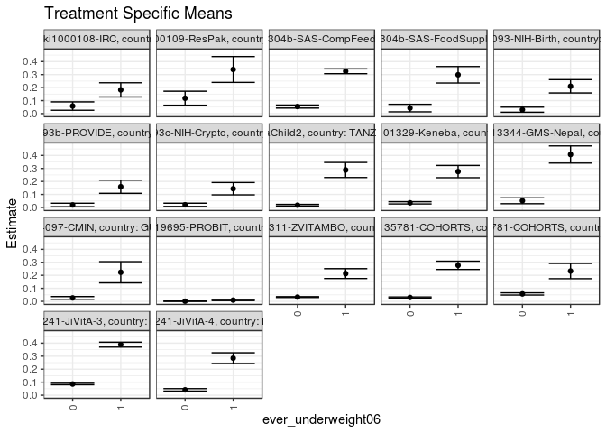

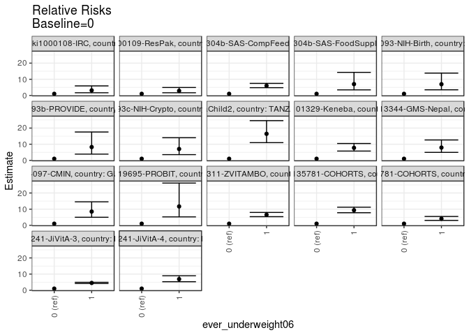

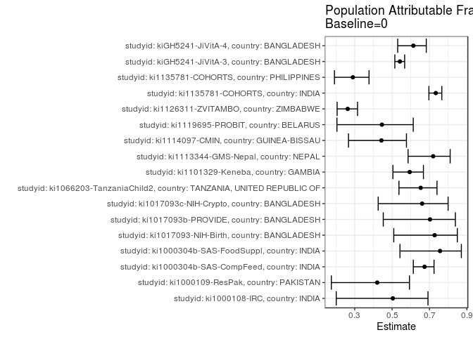

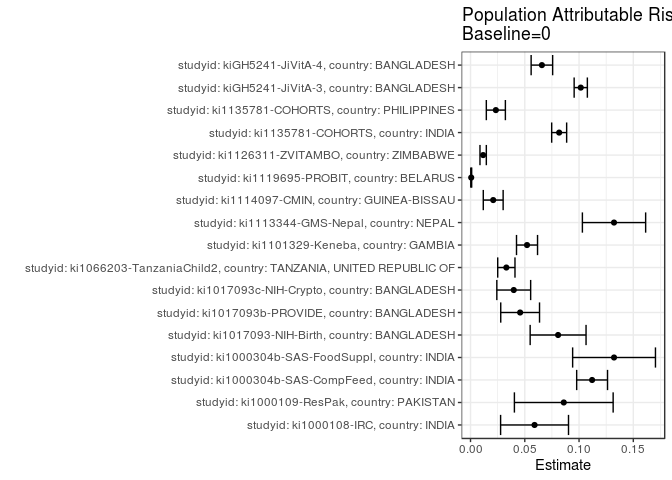

## Results Table

### Parameter: TSM

| studyid | country | intervention_level | baseline_level | estimate | ci_lower | ci_upper |
| --- | --- | --- | --- | --- | --- | --- |
| ki1000108-IRC | INDIA | 0 | NA | 0.0580669 | 0.0258532 | 0.0902807 |
| ki1000108-IRC | INDIA | 1 | NA | 0.1826902 | 0.1282048 | 0.2371755 |
| ki1000109-ResPak | PAKISTAN | 0 | NA | 0.1184171 | 0.0647107 | 0.1721236 |
| ki1000109-ResPak | PAKISTAN | 1 | NA | 0.3392674 | 0.2398394 | 0.4386955 |
| ki1000304b-SAS-CompFeed | INDIA | 0 | NA | 0.0542741 | 0.0425500 | 0.0659981 |
| ki1000304b-SAS-CompFeed | INDIA | 1 | NA | 0.3254812 | 0.3068253 | 0.3441370 |
| ki1000304b-SAS-FoodSuppl | INDIA | 0 | NA | 0.0425532 | 0.0136629 | 0.0714435 |
| ki1000304b-SAS-FoodSuppl | INDIA | 1 | NA | 0.2985075 | 0.2351645 | 0.3618504 |
| ki1017093-NIH-Birth | BANGLADESH | 0 | NA | 0.0302013 | 0.0107524 | 0.0496503 |
| ki1017093-NIH-Birth | BANGLADESH | 1 | NA | 0.2098765 | 0.1586286 | 0.2611245 |
| ki1017093b-PROVIDE | BANGLADESH | 0 | NA | 0.0193237 | 0.0060525 | 0.0325948 |
| ki1017093b-PROVIDE | BANGLADESH | 1 | NA | 0.1592040 | 0.1085836 | 0.2098244 |
| ki1017093c-NIH-Crypto | BANGLADESH | 0 | NA | 0.0204457 | 0.0081184 | 0.0327729 |
| ki1017093c-NIH-Crypto | BANGLADESH | 1 | NA | 0.1441976 | 0.0967459 | 0.1916494 |
| ki1066203-TanzaniaChild2 | TANZANIA, UNITED REPUBLIC OF | 0 | NA | 0.0175306 | 0.0114078 | 0.0236534 |
| ki1066203-TanzaniaChild2 | TANZANIA, UNITED REPUBLIC OF | 1 | NA | 0.2881428 | 0.2303753 | 0.3459103 |
| ki1101329-Keneba | GAMBIA | 0 | NA | 0.0355597 | 0.0268635 | 0.0442559 |
| ki1101329-Keneba | GAMBIA | 1 | NA | 0.2761529 | 0.2291590 | 0.3231468 |
| ki1113344-GMS-Nepal | NEPAL | 0 | NA | 0.0514467 | 0.0288867 | 0.0740066 |
| ki1113344-GMS-Nepal | NEPAL | 1 | NA | 0.4073299 | 0.3413860 | 0.4732739 |
| ki1114097-CMIN | GUINEA-BISSAU | 0 | NA | 0.0262867 | 0.0159279 | 0.0366456 |
| ki1114097-CMIN | GUINEA-BISSAU | 1 | NA | 0.2236117 | 0.1420639 | 0.3051595 |
| ki1119695-PROBIT | BELARUS | 0 | NA | 0.0008019 | 0.0000540 | 0.0015498 |
| ki1119695-PROBIT | BELARUS | 1 | NA | 0.0093614 | 0.0053752 | 0.0133475 |
| ki1126311-ZVITAMBO | ZIMBABWE | 0 | NA | 0.0326855 | 0.0296115 | 0.0357594 |
| ki1126311-ZVITAMBO | ZIMBABWE | 1 | NA | 0.2134759 | 0.1757452 | 0.2512066 |
| ki1135781-COHORTS | INDIA | 0 | NA | 0.0296386 | 0.0254535 | 0.0338237 |
| ki1135781-COHORTS | INDIA | 1 | NA | 0.2768516 | 0.2450106 | 0.3086927 |
| ki1135781-COHORTS | PHILIPPINES | 0 | NA | 0.0571120 | 0.0485806 | 0.0656434 |
| ki1135781-COHORTS | PHILIPPINES | 1 | NA | 0.2328458 | 0.1742513 | 0.2914403 |
| kiGH5241-JiVitA-3 | BANGLADESH | 0 | NA | 0.0859172 | 0.0801615 | 0.0916730 |
| kiGH5241-JiVitA-3 | BANGLADESH | 1 | NA | 0.3884807 | 0.3696124 | 0.4073490 |
| kiGH5241-JiVitA-4 | BANGLADESH | 0 | NA | 0.0413494 | 0.0320680 | 0.0506308 |
| kiGH5241-JiVitA-4 | BANGLADESH | 1 | NA | 0.2845732 | 0.2432007 | 0.3259457 |

### Parameter: E(Y)

| studyid | country | intervention_level | baseline_level | estimate | ci_lower | ci_upper |
| --- | --- | --- | --- | --- | --- | --- |
| ki1000108-IRC | INDIA | NA | NA | 0.1170732 | 0.0859146 | 0.1482317 |
| ki1000109-ResPak | PAKISTAN | NA | NA | 0.2043478 | 0.1521230 | 0.2565727 |
| ki1000304b-SAS-CompFeed | INDIA | NA | NA | 0.1663067 | 0.1478935 | 0.1847199 |
| ki1000304b-SAS-FoodSuppl | INDIA | NA | NA | 0.1748072 | 0.1370161 | 0.2125983 |
| ki1017093-NIH-Birth | BANGLADESH | NA | NA | 0.1109057 | 0.0844206 | 0.1373909 |
| ki1017093b-PROVIDE | BANGLADESH | NA | NA | 0.0650407 | 0.0455353 | 0.0845460 |
| ki1017093c-NIH-Crypto | BANGLADESH | NA | NA | 0.0602740 | 0.0429977 | 0.0775502 |
| ki1066203-TanzaniaChild2 | TANZANIA, UNITED REPUBLIC OF | NA | NA | 0.0505451 | 0.0409848 | 0.0601054 |
| ki1101329-Keneba | GAMBIA | NA | NA | 0.0876266 | 0.0759950 | 0.0992582 |
| ki1113344-GMS-Nepal | NEPAL | NA | NA | 0.1836735 | 0.1523490 | 0.2149980 |
| ki1114097-CMIN | GUINEA-BISSAU | NA | NA | 0.0471976 | 0.0341581 | 0.0602372 |
| ki1119695-PROBIT | BELARUS | NA | NA | 0.0014461 | 0.0004206 | 0.0024716 |
| ki1126311-ZVITAMBO | ZIMBABWE | NA | NA | 0.0443281 | 0.0404267 | 0.0482294 |
| ki1135781-COHORTS | INDIA | NA | NA | 0.1113208 | 0.1038935 | 0.1187480 |
| ki1135781-COHORTS | PHILIPPINES | NA | NA | 0.0804557 | 0.0703953 | 0.0905161 |
| kiGH5241-JiVitA-3 | BANGLADESH | NA | NA | 0.1874928 | 0.1809540 | 0.1940315 |
| kiGH5241-JiVitA-4 | BANGLADESH | NA | NA | 0.1071157 | 0.0969298 | 0.1173015 |

### Parameter: RR

| studyid | country | intervention_level | baseline_level | estimate | ci_lower | ci_upper |
| --- | --- | --- | --- | --- | --- | --- |
| ki1000108-IRC | INDIA | 0 | 0 | 1.000000 | 1.000000 | 1.000000 |
| ki1000108-IRC | INDIA | 1 | 0 | 3.146199 | 1.674497 | 5.911371 |
| ki1000109-ResPak | PAKISTAN | 0 | 0 | 1.000000 | 1.000000 | 1.000000 |
| ki1000109-ResPak | PAKISTAN | 1 | 0 | 2.865020 | 1.669748 | 4.915914 |
| ki1000304b-SAS-CompFeed | INDIA | 0 | 0 | 1.000000 | 1.000000 | 1.000000 |
| ki1000304b-SAS-CompFeed | INDIA | 1 | 0 | 5.996994 | 4.813144 | 7.472026 |
| ki1000304b-SAS-FoodSuppl | INDIA | 0 | 0 | 1.000000 | 1.000000 | 1.000000 |
| ki1000304b-SAS-FoodSuppl | INDIA | 1 | 0 | 7.014925 | 3.444331 | 14.287003 |
| ki1017093-NIH-Birth | BANGLADESH | 0 | 0 | 1.000000 | 1.000000 | 1.000000 |
| ki1017093-NIH-Birth | BANGLADESH | 1 | 0 | 6.949245 | 3.490055 | 13.837033 |
| ki1017093b-PROVIDE | BANGLADESH | 0 | 0 | 1.000000 | 1.000000 | 1.000000 |
| ki1017093b-PROVIDE | BANGLADESH | 1 | 0 | 8.238806 | 3.865305 | 17.560819 |
| ki1017093c-NIH-Crypto | BANGLADESH | 0 | 0 | 1.000000 | 1.000000 | 1.000000 |
| ki1017093c-NIH-Crypto | BANGLADESH | 1 | 0 | 7.052728 | 3.546845 | 14.024005 |
| ki1066203-TanzaniaChild2 | TANZANIA, UNITED REPUBLIC OF | 0 | 0 | 1.000000 | 1.000000 | 1.000000 |
| ki1066203-TanzaniaChild2 | TANZANIA, UNITED REPUBLIC OF | 1 | 0 | 16.436526 | 10.986580 | 24.589943 |
| ki1101329-Keneba | GAMBIA | 0 | 0 | 1.000000 | 1.000000 | 1.000000 |
| ki1101329-Keneba | GAMBIA | 1 | 0 | 7.765893 | 5.768761 | 10.454428 |
| ki1113344-GMS-Nepal | NEPAL | 0 | 0 | 1.000000 | 1.000000 | 1.000000 |
| ki1113344-GMS-Nepal | NEPAL | 1 | 0 | 7.917516 | 4.961569 | 12.634525 |
| ki1114097-CMIN | GUINEA-BISSAU | 0 | 0 | 1.000000 | 1.000000 | 1.000000 |
| ki1114097-CMIN | GUINEA-BISSAU | 1 | 0 | 8.506638 | 4.972989 | 14.551184 |
| ki1119695-PROBIT | BELARUS | 0 | 0 | 1.000000 | 1.000000 | 1.000000 |
| ki1119695-PROBIT | BELARUS | 1 | 0 | 11.674411 | 5.212262 | 26.148316 |
| ki1126311-ZVITAMBO | ZIMBABWE | 0 | 0 | 1.000000 | 1.000000 | 1.000000 |
| ki1126311-ZVITAMBO | ZIMBABWE | 1 | 0 | 6.531219 | 5.344856 | 7.980911 |
| ki1135781-COHORTS | INDIA | 0 | 0 | 1.000000 | 1.000000 | 1.000000 |
| ki1135781-COHORTS | INDIA | 1 | 0 | 9.340915 | 7.786644 | 11.205429 |
| ki1135781-COHORTS | PHILIPPINES | 0 | 0 | 1.000000 | 1.000000 | 1.000000 |
| ki1135781-COHORTS | PHILIPPINES | 1 | 0 | 4.077002 | 3.042280 | 5.463648 |
| kiGH5241-JiVitA-3 | BANGLADESH | 0 | 0 | 1.000000 | 1.000000 | 1.000000 |
| kiGH5241-JiVitA-3 | BANGLADESH | 1 | 0 | 4.521569 | 4.163424 | 4.910522 |
| kiGH5241-JiVitA-4 | BANGLADESH | 0 | 0 | 1.000000 | 1.000000 | 1.000000 |
| kiGH5241-JiVitA-4 | BANGLADESH | 1 | 0 | 6.882158 | 5.274669 | 8.979539 |

### Parameter: PAR

| studyid | country | intervention_level | baseline_level | estimate | ci_lower | ci_upper |
| --- | --- | --- | --- | --- | --- | --- |
| ki1000108-IRC | INDIA | 0 | NA | 0.0590062 | 0.0277216 | 0.0902909 |
| ki1000109-ResPak | PAKISTAN | 0 | NA | 0.0859307 | 0.0404347 | 0.1314266 |
| ki1000304b-SAS-CompFeed | INDIA | 0 | NA | 0.1120326 | 0.0978203 | 0.1262449 |
| ki1000304b-SAS-FoodSuppl | INDIA | 0 | NA | 0.1322540 | 0.0940956 | 0.1704124 |
| ki1017093-NIH-Birth | BANGLADESH | 0 | NA | 0.0807044 | 0.0549555 | 0.1064533 |
| ki1017093b-PROVIDE | BANGLADESH | 0 | NA | 0.0457170 | 0.0278436 | 0.0635904 |
| ki1017093c-NIH-Crypto | BANGLADESH | 0 | NA | 0.0398283 | 0.0242443 | 0.0554123 |
| ki1066203-TanzaniaChild2 | TANZANIA, UNITED REPUBLIC OF | 0 | NA | 0.0330145 | 0.0250595 | 0.0409694 |
| ki1101329-Keneba | GAMBIA | 0 | NA | 0.0520669 | 0.0423761 | 0.0617577 |
| ki1113344-GMS-Nepal | NEPAL | 0 | NA | 0.1322268 | 0.1030853 | 0.1613683 |
| ki1114097-CMIN | GUINEA-BISSAU | 0 | NA | 0.0209109 | 0.0117623 | 0.0300596 |
| ki1119695-PROBIT | BELARUS | 0 | NA | 0.0006443 | 0.0002324 | 0.0010561 |
| ki1126311-ZVITAMBO | ZIMBABWE | 0 | NA | 0.0116426 | 0.0087168 | 0.0145684 |
| ki1135781-COHORTS | INDIA | 0 | NA | 0.0816822 | 0.0747864 | 0.0885779 |
| ki1135781-COHORTS | PHILIPPINES | 0 | NA | 0.0233437 | 0.0145642 | 0.0321231 |
| kiGH5241-JiVitA-3 | BANGLADESH | 0 | NA | 0.1015755 | 0.0954882 | 0.1076628 |
| kiGH5241-JiVitA-4 | BANGLADESH | 0 | NA | 0.0657663 | 0.0558551 | 0.0756774 |

### Parameter: PAF

| studyid | country | intervention_level | baseline_level | estimate | ci_lower | ci_upper |
| --- | --- | --- | --- | --- | --- | --- |
| ki1000108-IRC | INDIA | 0 | NA | 0.5040116 | 0.2011969 | 0.6920336 |
| ki1000109-ResPak | PAKISTAN | 0 | NA | 0.4205119 | 0.1751615 | 0.5928822 |
| ki1000304b-SAS-CompFeed | INDIA | 0 | NA | 0.6736508 | 0.6136235 | 0.7243523 |
| ki1000304b-SAS-FoodSuppl | INDIA | 0 | NA | 0.7565707 | 0.5420949 | 0.8705893 |
| ki1017093-NIH-Birth | BANGLADESH | 0 | NA | 0.7276846 | 0.5090700 | 0.8489485 |
| ki1017093b-PROVIDE | BANGLADESH | 0 | NA | 0.7028985 | 0.4528294 | 0.8386805 |
| ki1017093c-NIH-Crypto | BANGLADESH | 0 | NA | 0.6607880 | 0.4256923 | 0.7996461 |
| ki1066203-TanzaniaChild2 | TANZANIA, UNITED REPUBLIC OF | 0 | NA | 0.6531683 | 0.5367896 | 0.7403076 |
| ki1101329-Keneba | GAMBIA | 0 | NA | 0.5941905 | 0.5044974 | 0.6676478 |
| ki1113344-GMS-Nepal | NEPAL | 0 | NA | 0.7199014 | 0.5855331 | 0.8107081 |
| ki1114097-CMIN | GUINEA-BISSAU | 0 | NA | 0.4430499 | 0.2668646 | 0.5768948 |
| ki1119695-PROBIT | BELARUS | 0 | NA | 0.4455072 | 0.2050111 | 0.6132496 |
| ki1126311-ZVITAMBO | ZIMBABWE | 0 | NA | 0.2626463 | 0.2060322 | 0.3152236 |
| ki1135781-COHORTS | INDIA | 0 | NA | 0.7337549 | 0.6969391 | 0.7660984 |
| ki1135781-COHORTS | PHILIPPINES | 0 | NA | 0.2901432 | 0.1917250 | 0.3765777 |
| kiGH5241-JiVitA-3 | BANGLADESH | 0 | NA | 0.5417570 | 0.5146888 | 0.5673156 |
| kiGH5241-JiVitA-4 | BANGLADESH | 0 | NA | 0.6139742 | 0.5300134 | 0.6829358 |